# What’s Your Malfunction?

Lillian Holden

Due for Peer Commentary October 25th by 5 PM

## Part 1

### Create Two Data Sets with Normal Distribution

```r
set.seed(0)
data.frame <- rnorm(50,5,1)
additional.data.frame <- rnorm(50,6,1)
```

### Create one Data Set without Normal Distribution

```r
baddistribution <- c(1, 2, 3, 4, 5)
baddistribution
```

```
## [1] 1 2 3 4 5
```

### Create the Function

I am unsure of how to add code to to test (n∗p>5 and n∗(1−p)>5). Any suggestions?

```r
z.prop.test <- function (x, y = NULL, alternative = "two.sided", mu, sigma.x,
    sigma.y = NULL, conf.level = 0.95)
{
    choices <- c("two.sided", "greater", "less")
    alt <- pmatch(alternative, choices)
    alternative <- choices[alt]

    if (!is.null(y)) {
        dname <- paste(deparse(substitute(x)), "and", paste(deparse(substitute(y))))
    }

    else {
        dname <- deparse(substitute(x))
    }
    mx <- mean(x)
    estimate <- mx

    if (is.null(y)) {
        stderr <- sigma.x/sqrt(mx)
        zobs <- (mx - mu)/stderr
        method <- c("One-sample z-Test")
        names(estimate) <- c("mean of x")
    }
       if (is.null(sigma.y)) {
        stderr <- sigma.x/sqrt(mx)
        zobs <- (mx - mu)/stderr
        method <- c("One-sample z-Test")
        names(estimate) <- c("mean of x")
    }
    else {
        my <- mean(y)
        method <- c("Two-sample z-Test")
        estimate <- c(mx, my)
        names(estimate) <- c("mean of x", "mean of y")
        stderr <- sqrt(((sigma.x^2)/mx) + ((sigma.y^2)/my))
        zobs <- (mx - my - mu)/stderr
    }
    if (alternative == "less") {
        pval <- pnorm(zobs)
        cint <- c(NA, zobs * stderr + qnorm(conf.level) * stderr)
    }
    else if (alternative == "greater") {
        pval <- 1 - pnorm(zobs)
        cint <- c(zobs * stderr - qnorm(conf.level) * stderr,
            NA)
    }
    else {
        pval <- 2 * pnorm(-abs(zobs))
        alpha <- 1 - conf.level
        cint <- c(zobs * stderr - qnorm((1 - alpha/2)) * stderr,
            zobs * stderr + qnorm((1 - alpha/2)) * stderr)
    }
    cint <- cint + mu
    names(zobs) <- "z"
    if (!is.null(y))
        names(mu) <- "difference in means"
     if (!is.null(x))
        names(mu) <- "difference in means"

    else names(mu) <- "mean"
    attr(cint, "conf.level") <- conf.level
    rval <- list(statistic = zobs, p.value = pval, conf.int = cint,
        estimate = estimate, null.value = mu, alternative = alternative,
        method = method, data.name = dname)
    attr(rval, "class") <- "htest"
    return(rval)
}
```

### Test to See if The Function Works with Multiple Scenerios

```r
#y and sigma.y = NULL
z.prop.test(data.frame, y = NULL, alternative = "two.sided", mu = 0, sigma.x = 2, sigma.y = NULL, conf.level = 0.95)
```

```
##
##  One-sample z-Test
##
## data:  data.frame
## z = 5.6304, p-value = 1.798e-08
## alternative hypothesis: true difference in means is not equal to 0
## 95 percent confidence interval:
##  3.275066 6.772796
## sample estimates:
## mean of x
##  5.023931
```

```r
#sigma.y = NULL
z.prop.test(data.frame, y=additional.data.frame, alternative = "two.sided", mu = 0, sigma.x = 2, sigma.y = NULL, conf.level = 0.95)
```

```
##
##  One-sample z-Test
##
## data:  data.frame and additional.data.frame
## z = 5.6304, p-value = 1.798e-08
## alternative hypothesis: true difference in means is not equal to 0
## 95 percent confidence interval:
##  3.275066 6.772796
## sample estimates:
## mean of x
##  5.023931
```

```r
#all information included
z.prop.test(data.frame, y=additional.data.frame, alternative = "two.sided", mu = 0, sigma.x = 2, sigma.y = 3, conf.level = 0.95)
```

```
##
##  Two-sample z-Test
##
## data:  data.frame and additional.data.frame
## z = -0.65903, p-value = 0.5099
## alternative hypothesis: true difference in means is not equal to 0
## 95 percent confidence interval:
##  -3.963993  1.969044
## sample estimates:
## mean of x mean of y
##  5.023931  6.021406
```

## Part 2

```r
library(curl)
```

```r
library(ggplot2)
library(tidyverse)
```

### Import the Data Set

```r
f <- curl("https://raw.githubusercontent.com/fuzzyatelin/fuzzyatelin.github.io/master/AN588_Fall23/KamilarAndCooperData.csv")
d <- read.csv(f, header = TRUE, sep = ",", stringsAsFactors = FALSE) #Assign D as the vector for the data set
head(d)
```

```
##               Scientific_Name          Family          Genus      Species
## 1 Allenopithecus_nigroviridis Cercopithecidae Allenopithecus nigroviridis
## 2         Allocebus_trichotis Cercopithecidae      Allocebus    trichotis
## 3           Alouatta_belzebul        Atelidae       Alouatta     belzebul
## 4             Alouatta_caraya        Atelidae       Alouatta       caraya
## 5            Alouatta_guariba        Atelidae       Alouatta      guariba
## 6           Alouatta_palliata        Atelidae       Alouatta     palliata
##   Brain_Size_Species_Mean Brain_Size_Female_Mean   Brain_size_Ref
## 1                   58.02                  53.70 Isler et al 2008
## 2                      NA                     NA
## 3                   52.84                  51.19 Isler et al 2008
## 4                   52.63                  47.80 Isler et al 2008
## 5                   51.70                  49.08 Isler et al 2008
## 6                   49.88                  48.04 Isler et al 2008
##   Body_mass_male_mean Body_mass_female_mean Mass_Dimorphism
```

[output cut: 62 more lines]

### Plot the variables in a Scatterplot

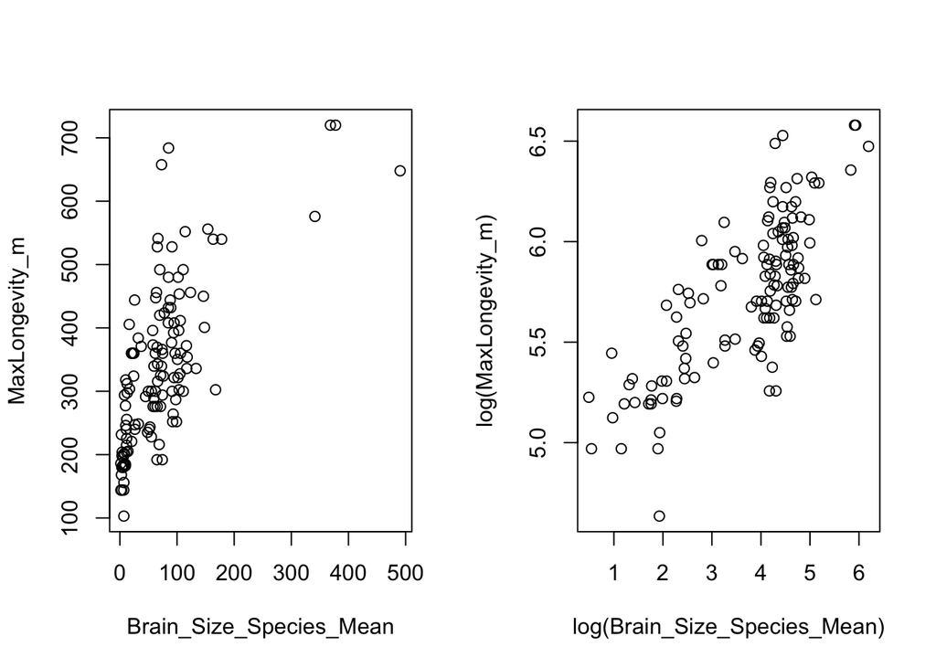

```r
par(mfrow = c(1, 2))
plot(data=d, MaxLongevity_m ~ Brain_Size_Species_Mean)
plot(data=d, log(MaxLongevity_m) ~ log(Brain_Size_Species_Mean))
```

### Add A Fitted Line to the Scatterplots - Determine the Intercept(B0) and Slope (B1)

```r
mI <- lm(MaxLongevity_m ~ Brain_Size_Species_Mean, data = d)
summary(mI)
```

```
##
## Call:
## lm(formula = MaxLongevity_m ~ Brain_Size_Species_Mean, data = d)
##
## Residuals:
##     Min      1Q  Median      3Q     Max
## -198.27  -61.92  -17.78   56.16  331.36
##
## Coefficients:
##                         Estimate Std. Error t value Pr(>|t|)
## (Intercept)             248.9523    11.1111   22.41   <2e-16 ***
## Brain_Size_Species_Mean   1.2180     0.1101   11.06   <2e-16 ***
## ---
## Signif. codes:  0 '***' 0.001 '**' 0.01 '*' 0.05 '.' 0.1 ' ' 1
##
## Residual standard error: 90.91 on 126 degrees of freedom
##   (85 observations deleted due to missingness)
## Multiple R-squared:  0.4928, Adjusted R-squared:  0.4887
## F-statistic: 122.4 on 1 and 126 DF,  p-value: < 2.2e-16
```

```r
mII <-  lm(log(MaxLongevity_m) ~ log(Brain_Size_Species_Mean), data = d)
summary(mII)
```

```
##
## Call:
## lm(formula = log(MaxLongevity_m) ~ log(Brain_Size_Species_Mean),
##     data = d)
##
## Residuals:
##     Min      1Q  Median      3Q     Max
## -0.6955 -0.1750 -0.0097  0.1788  0.6084
##
## Coefficients:
##                              Estimate Std. Error t value Pr(>|t|)
## (Intercept)                   4.87895    0.06907   70.63   <2e-16 ***
## log(Brain_Size_Species_Mean)  0.23415    0.01781   13.15   <2e-16 ***
## ---
## Signif. codes:  0 '***' 0.001 '**' 0.01 '*' 0.05 '.' 0.1 ' ' 1
##
## Residual standard error: 0.2485 on 126 degrees of freedom
##   (85 observations deleted due to missingness)
## Multiple R-squared:  0.5784, Adjusted R-squared:  0.5751
## F-statistic: 172.9 on 1 and 126 DF,  p-value: < 2.2e-16
```

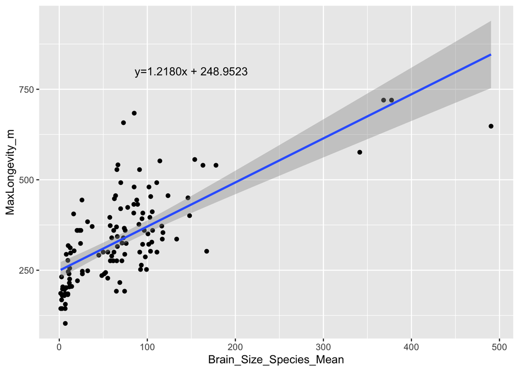

```r
par(mfrow = c(1, 2))
g <- ggplot(data = d, aes(x = Brain_Size_Species_Mean, y = MaxLongevity_m))
g <- g + geom_point()
g <- g + geom_smooth(method = "lm", formula = y ~ x)
g + annotate("text", x = 150, y = 800, label = "y=1.2180x + 248.9523")
```

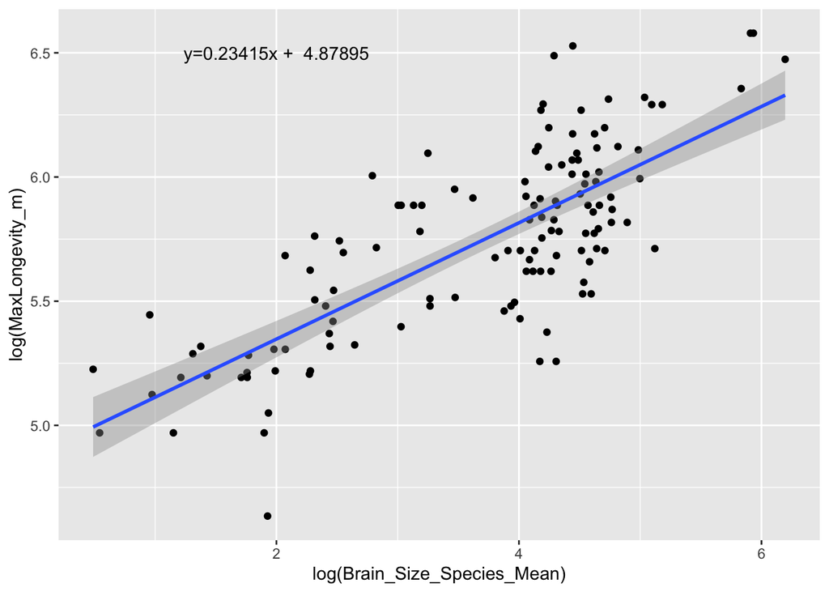

```r
h <- ggplot(data = d, aes(x = log(Brain_Size_Species_Mean), y = log(MaxLongevity_m)))
h <- h + geom_point()
h <- h + geom_smooth(method = "lm", formula = y ~ x)
h + annotate("text", x = 2, y = 6.5, label = "y=0.23415x +  4.87895")
```

### Identify and interpret the point estimate of the slope (β1), as well as the outcome of the test associated with the hypotheses H0: β1 = 0; HA: β1 ≠ 0. Also, find a 90 percent CI for the slope (β1) parameter.

- The estimate of the slope B1 for MaxLongevity_m ~ Brain_Size_Species_Mean is 1.2180. When B1 equals 0, y is equal to 248.9523. When B1 does not equal zero, it is the expected change in units of y for every 1 unit of change in x.

-The estimate of the slope B1 for log(MaxLongevity_m) ~ log(Brain_Size_Species_Mean) is 0.23415. When B1 equals 0, y is equal to 4.87895. When B1 does not equal zero, it is the expected change in units of y for every 1 unit of change in x.

### Find a 90% Confidence Interval Based on Each B1(m) Parameter

```r
ciI <- confint(mI, level = 0.90)
ciI
```

```
##                                5 %      95 %
## (Intercept)             230.540738 267.36379
## Brain_Size_Species_Mean   1.035571   1.40041
```

```r
ciII <- confint(mII, level = 0.90)
ciII
```

```
##                                    5 %      95 %
## (Intercept)                  4.7644934 4.9934084
## log(Brain_Size_Species_Mean) 0.2046396 0.2636595
```

### Plot the 90% CI and Predicion

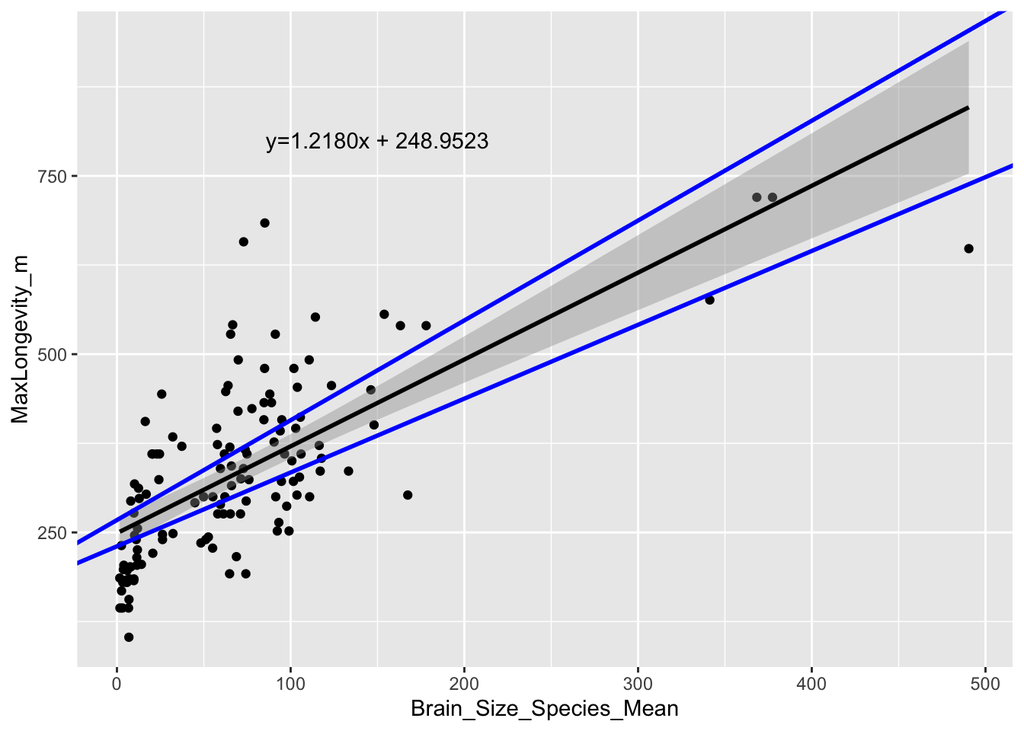

```r
g <- ggplot(data = d, aes(x = Brain_Size_Species_Mean, y = MaxLongevity_m))
g <- g + geom_point()
g <- g + geom_smooth(method = "lm", formula = y ~ x, color = "black")
g <- g + geom_abline(intercept = 230.540738, slope = 1.035571, linewidth = 1, color = "blue")
g <- g + geom_abline(intercept = 267.36379, slope = 1.40041, linewidth = 1, color = "blue")
g + annotate("text", x = 150, y = 800, label = "y=1.2180x + 248.9523")
```

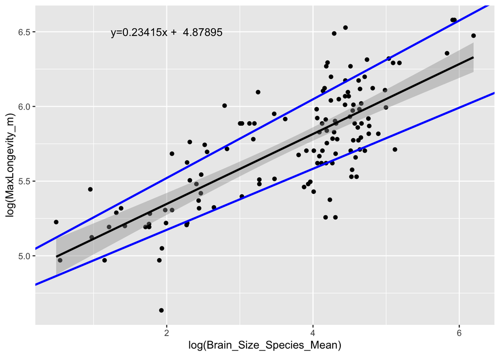

```r
h <- ggplot(data = d, aes(x = log(Brain_Size_Species_Mean), y = log(MaxLongevity_m)))
h <- h + geom_point()
h <- h + geom_smooth(method = "lm", formula = y ~ x, color = "black")
h <- h + geom_abline(intercept = 4.7644934, slope = 0.2046396, linewidth = 1, color = "blue")
h <- h + geom_abline(intercept = 4.9934084, slope = 0.2636595, linewidth = 1, color = "blue")
h + annotate("text", x = 2, y = 6.5, label = "y=0.23415x +  4.87895")
```

## I can’t Figure out How to Make A Legend :( Any suggestions?

```r
cipredI <- predict(mI, newdata = data.frame(Brain_Size_Species_Mean = 800), interval = "confidence",
    level = 0.90)
cipredI
```

```
##        fit      lwr      upr
## 1 1223.345 1089.461 1357.228
```

### I do trust the model to make that prediction because the fit was ~1223 with a 90% CI. The point is predicted to be between ~1089 and ~1357. When 800 is typed into the model equation alone y=1.2180x + 248.9523, it gets ~1223.